# Rethinking_week13_2019-08-14

Stacey Harmer

8/13/2019

*NOTE: If code fails later, first run code for week 12*

Video: The remainder of Conditional Manatees https://youtu.be/QhHfo6-Bx8o

last time: don’t split your dataset; instead, add index variable to the slope. different slope for each continent. this week starts around 32:55

Interpretations are symmetric. 40:45 - submodel - linear model. like regression within regression.

tulip model: when no interaction between water and shade, the slope (blooms vs water) is the same no matter what the shade state.

Remember the link function for inspecting posterior (or the prior, for that matter)

## Book: Remainder of Chapter 8

### 8.2 Symmetry of interactions

we said slope is conditional on continent. But could also say intercept is conditional on ruggedness.

or, “association of being in Africa with log GDP depends upon ruggedness”  
‘hold ruggedness constant, and compute differnece between a nation in Africa and one outside Africa’

first, catch up

code 8.1

```r
library(rethinking)
data(rugged)
d <- rugged
# make log version of outcome
d$log_gdp <- log( d$rgdppc_2000 )
# extract countries with GDP data
dd <- d[ complete.cases(d$rgdppc_2000) , ]
# rescale variables
dd$log_gdp_std <- dd$log_gdp / mean(dd$log_gdp)
dd$rugged_std <- dd$rugged / max(dd$rugged)
# split countries into Africa and not-Africa
d.A1 <- dd[ dd$cont_africa==1 , ] # Africa
d.A0 <- dd[ dd$cont_africa==0 , ] # not Africa
```

code 8.2

```r
m8.1 <- quap(
  alist(
    log_gdp_std ~ dnorm( mu , sigma ) ,
    mu <- a + b*( rugged_std - 0.215 ) ,
    a ~ dnorm( 1 , 1 ) ,
    b ~ dnorm( 0 , 1 ) ,
    sigma ~ dexp( 1 )
  ) , data=d.A1 )
```

Now check out the priors; use link function

code 8.3

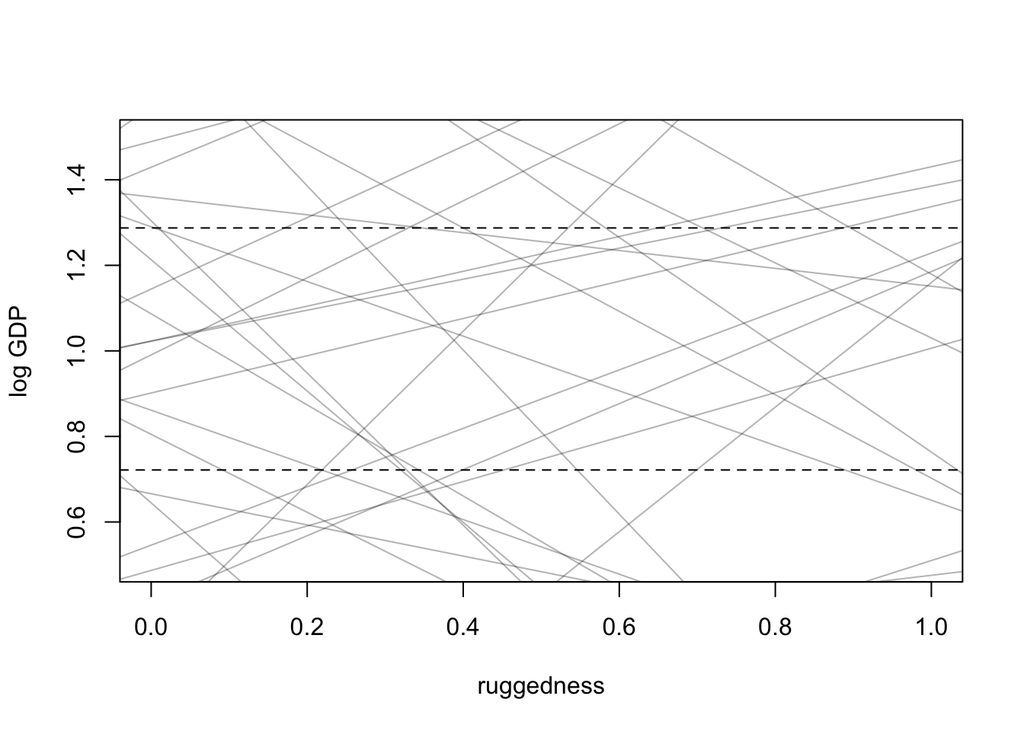

```r
set.seed(7)
prior <- extract.prior( m8.1 )

# set up the plot dimensions
plot( NULL , xlim=c(0,1) , ylim=c(0.5,1.5) ,
      xlab="ruggedness" , ylab="log GDP" )
abline( h=min(dd$log_gdp_std) , lty=2 )
abline( h=max(dd$log_gdp_std) , lty=2 )

# draw 50 lines from the prior
rugged_seq <- seq( from=-0.1 , to=1.1 , length.out=30 )
mu <- link( m8.1 , post=prior , data=data.frame(rugged_std=rugged_seq) )
for ( i in 1:50 ) lines( rugged_seq , mu[i,] , col=col.alpha("black",0.3) )
```

code 8.4

```r
#sum( abs(prior$b) > 0.6 ) / length(prior$bR)

sum( abs(prior$b) > 0.6 ) / length(prior$b)
```

```
## [1] 0.545
```

code 8.5

```r
m8.1 <- quap(
  alist(
    log_gdp_std ~ dnorm( mu , sigma ) ,
    mu <- a + b*( rugged_std - 0.215 ) ,
    a ~ dnorm( 1 , 0.1 ) ,
    b ~ dnorm( 0 , 0.3 ) ,
    sigma ~ dexp(1)
  ) , data=d.A1 )
```

code 8.6. non-african countries

```r
# Non-African nations
m8.2 <- quap(
  alist(
    log_gdp_std ~ dnorm( mu , sigma ) ,
    mu <- a + b*( rugged_std - 0.215 ) ,
    a ~ dnorm( 1 , 0.1 ) ,
    b ~ dnorm( 0 , 0.25 ) ,
    sigma ~ dexp(1)
    ) ,
  data=d.A0 )
```

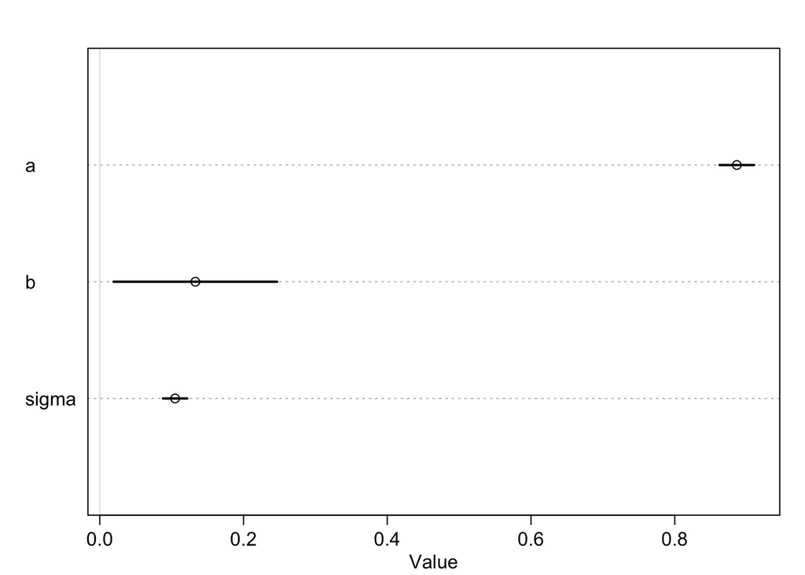

```r
plot(precis(m8.1))
```

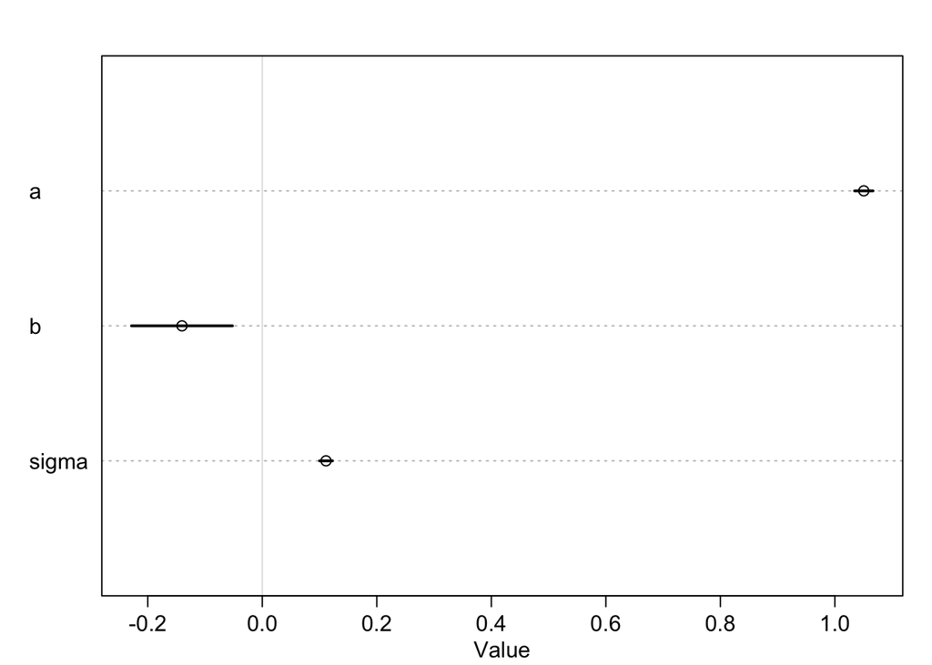

```r
plot(precis(m8.2))
```

code 8.7

```r
m8.3 <- quap(
  alist(
    log_gdp_std ~ dnorm( mu , sigma ) ,
    mu <- a + b*( rugged_std - 0.215 ) ,
    a ~ dnorm( 1 , 0.1 ) ,
    b ~ dnorm( 0 , 0.3 ) ,
    sigma ~ dexp( 1 )
  ) ,
  data=dd )
```

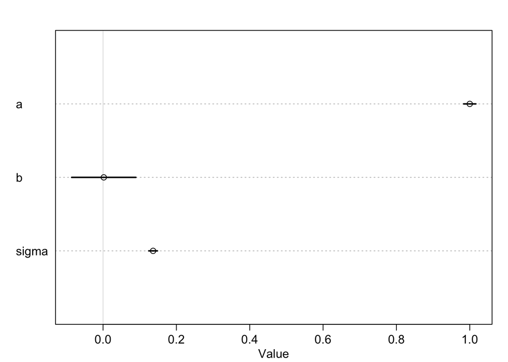

```r
plot(precis(m8.3))
```

code 8.8

```r
# make variable to index Africa (1) or not (2) 8.8
dd$cid <- ifelse( dd$cont_africa==1 , 1 , 2 )
```

code 8.9

```r
m8.4 <- quap(
  alist(
    log_gdp_std ~ dnorm( mu , sigma ) ,
    mu <- a[cid] + b*( rugged_std - 0.215 ) ,
    a[cid] ~ dnorm( 1 , 0.1 ) ,
    b ~ dnorm( 0 , 0.3 ) ,
    sigma ~ dexp( 1 )
  ) ,
  data=dd )
```

now compare

code 8.10

```r
compare(m8.3, m8.4)
```

```
##           WAIC    pWAIC   dWAIC       weight       SE      dSE
## m8.4 -252.2793 4.251978  0.0000 1.000000e+00 15.29497       NA
## m8.3 -188.7519 2.693455 63.5274 1.603984e-14 13.28923 15.14053
```

code 8.11

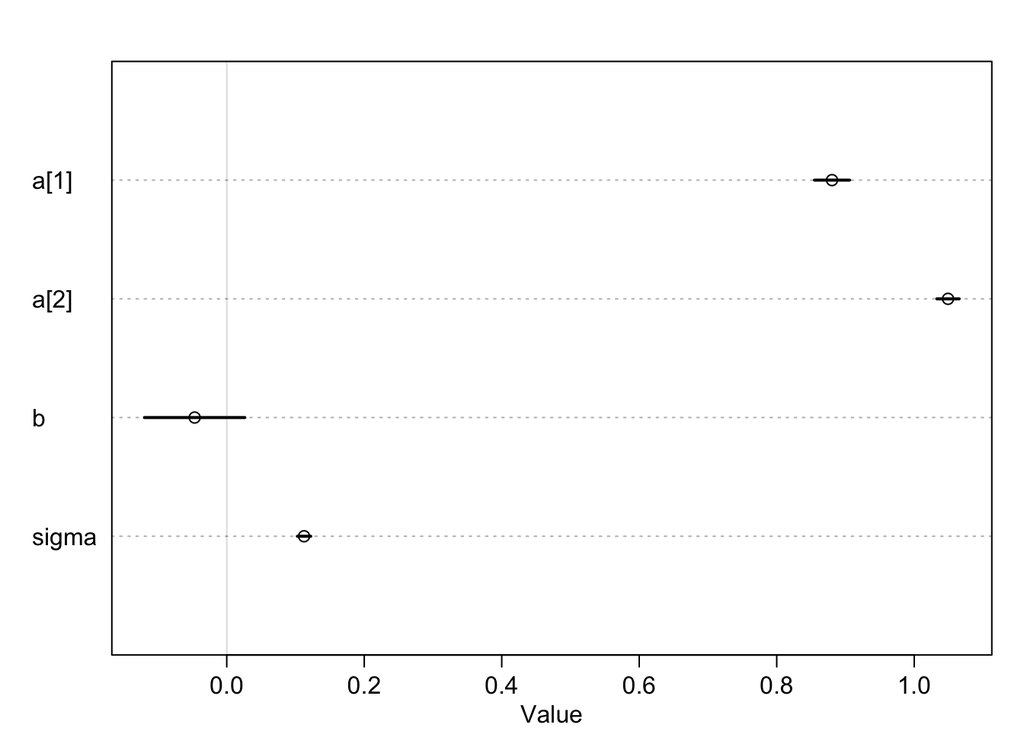

```r
plot(precis(m8.4, depth = 2))
```

code 8.12 plot posterior predictions

```r
rugged.seq <- seq( from=-0.1 , to=1.1 , length.out=30 )

# compute mu over samples, fixing cid=2
mu.NotAfrica <- link( m8.4 ,
                      data=data.frame( cid=2 , rugged_std=rugged.seq ) )

# compute mu over samples, fixing cid=1
mu.Africa <- link( m8.4 ,
                   data=data.frame( cid=1 , rugged_std=rugged.seq ) )

# summarize to means and intervals
mu.NotAfrica_mu <- apply( mu.NotAfrica , 2 , mean )
mu.NotAfrica_ci <- apply( mu.NotAfrica , 2 , PI , prob=0.97 )
mu.Africa_mu <- apply( mu.Africa , 2 , mean )
mu.Africa_ci <- apply( mu.Africa , 2 , PI , prob=0.97 )
```

now add an interaction effect: slope conditional on continent (in a DAG, an interaction is two arrows entering a varaible: R –> G <– C ) this is same as G = f(R, C)

code 8.13

```r
m8.5 <- quap(
  alist(
    log_gdp_std ~ dnorm( mu , sigma ) ,
    mu <- a[cid] + b[cid]*( rugged_std - 0.215 ) ,
    a[cid] ~ dnorm( 1 , 0.1 ) ,
    b[cid] ~ dnorm( 0 , 0.3 ) ,
    sigma ~ dexp( 1 )
  ) ,
  data=dd )
```

code 8.14

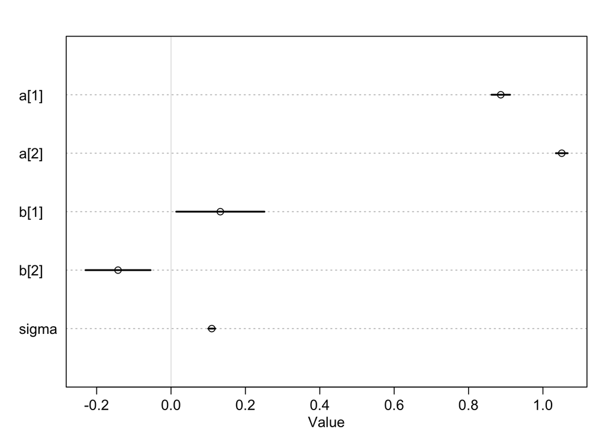

```r
plot(precis(m8.5, depth = 2))
```

compare! code 8.15

```r
compare(m8.3, m8.4, m8.5)
```

```
##           WAIC    pWAIC     dWAIC       weight       SE       dSE
## m8.5 -258.2581 5.608769  0.000000 9.544522e-01 15.26863        NA
## m8.4 -252.1734 4.288529  6.084752 4.554778e-02 15.29425  6.764469
## m8.3 -188.9108 2.616449 69.347319 8.340176e-16 13.34484 15.593212
```

Now look at the WAIC point by point.  
“the simplest approximation of how sensitive a model is the sample, and therefore the overfitting risk, is just the variance in log-probability”

code 8.16

```r
waic_list <- WAIC( m8.5 , pointwise=TRUE )
```

BUT what are we supposed to do with this?

code 8.17 - plot hte interaction

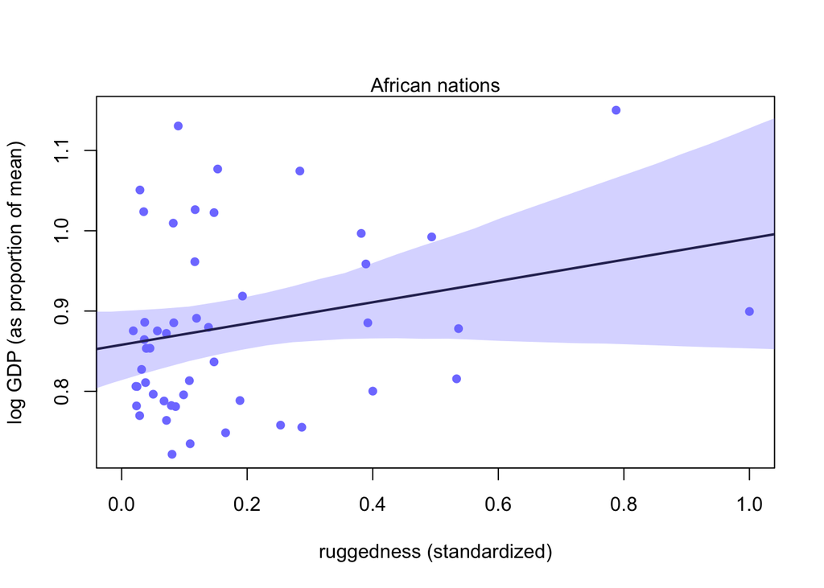

```r
# plot Africa - cid=1
plot( d.A1$rugged_std , d.A1$log_gdp_std , pch=16 , col=rangi2 ,
      xlab="ruggedness (standardized)" , ylab="log GDP (as proportion of mean)" ,
      xlim=c(0,1) )
mu <- link( m8.5 , data=data.frame( cid=1 , rugged_std=rugged_seq ) )
mu_mean <- apply( mu , 2 , mean )
mu_ci <- apply( mu , 2 , PI , prob=0.97 )
lines( rugged_seq , mu_mean , lwd=2 )
shade( mu_ci , rugged_seq , col=col.alpha(rangi2,0.3) )
mtext("African nations")
```

And,

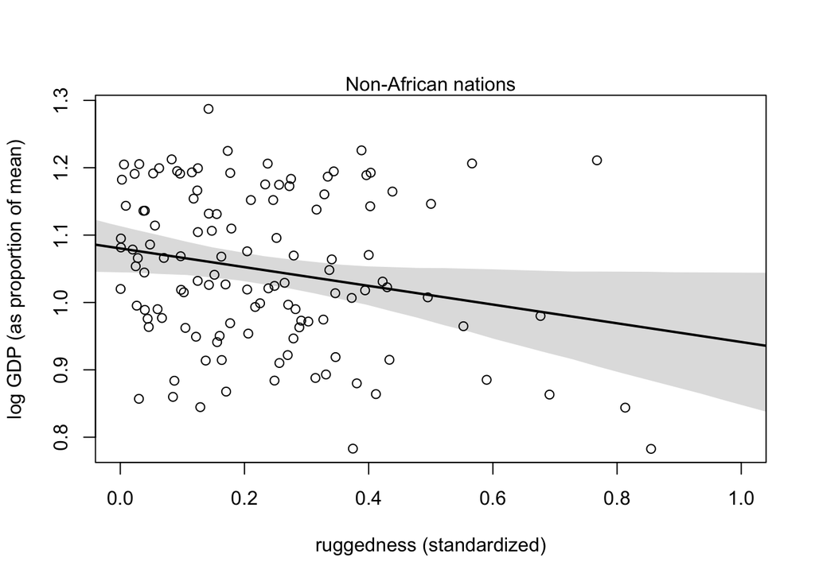

```r
# plot non-Africa - cid=2
plot( d.A0$rugged_std , d.A0$log_gdp_std , pch=1 , col="black" ,
      xlab="ruggedness (standardized)" , ylab="log GDP (as proportion of mean)" ,
      xlim=c(0,1) )
mu <- link( m8.5 , data=data.frame( cid=2 , rugged_std=rugged_seq ) )
mu_mean <- apply( mu , 2 , mean )
mu_ci <- apply( mu , 2 , PI , prob=0.97 )
lines( rugged_seq , mu_mean , lwd=2 )
shade( mu_ci , rugged_seq )
mtext("Non-African nations")
```

code 8.18

```r
rugged_seq <- seq(from=-0.2,to=1.2,length.out=30)
muA <- link( m8.5 , data=data.frame(cid=1,rugged_std=rugged_seq) )
muN <- link( m8.5 , data=data.frame(cid=2,rugged_std=rugged_seq) )
delta <- muA - muN
```

Counter-factual plotting. NO actual data; just imagined comparisons.

### 8.3 Continuous interactions

code 8.19

```r
data(tulips)
d <- tulips

str(d)
```

```
## 'data.frame':    27 obs. of  4 variables:
##  $ bed   : Factor w/ 3 levels "a","b","c": 1 1 1 1 1 1 1 1 1 2 ...
##  $ water : int  1 1 1 2 2 2 3 3 3 1 ...
##  $ shade : int  1 2 3 1 2 3 1 2 3 1 ...
##  $ blooms: num  0 0 111 183.5 59.2 ...
```

note that here we mean center the data, and scale outcome (blooms) by max

code 8.20

```r
d$blooms_std <- d$blooms / max(d$blooms)
d$water_cent <- d$water - mean(d$water)
d$shade_cent <- d$shade - mean(d$shade)
```

priors - for alpha, center at 0.5 (blooms half of max). beta are centered on 0.

```r
a <- rnorm(1e4, 0.5, 1)
sum( a < 0 | a > 1)/length(a)
```

```
## [1] 0.617
```

62% of intercepts greater than 1 and less than 0; that makes no sense!

```r
a <- rnorm(1e4, 0.5, 0.25)
sum( a < 0 | a > 1)/length(a)
```

```
## [1] 0.0449
```

That is more sensible.

what if slopes are normal, with SD = .25?

given above reasoning, SD of .25 would give 95% of slopes between -0.5 and 0.5. this might be too large effect

code 8.23

```r
m8.6 <- quap(
  alist(
    blooms_std ~ dnorm( mu , sigma ) ,
    mu <- a + bw*water_cent + bs*shade_cent ,
    a ~ dnorm( 0.5 , 0.25 ) ,
    bw ~ dnorm( 0 , 0.25 ) ,
    bs ~ dnorm( 0 , 0.25 ) ,
    sigma ~ dexp( 1 )
    ) ,
  data=d )
```

Recall this is the simple, no interaction model

p 256. To make an interaction model, we add another model within original one. (the slope of water includes a term that depends on shade)

How to define prior for new interaction parameter? assume if shade is high enough, water has 0 effect. see argument for setting bws same as bw

code 8.24

```r
m8.7 <- quap(
  alist(
    blooms_std ~ dnorm( mu , sigma ) ,
    mu <- a + bw*water_cent + bs*shade_cent + bws*water_cent*shade_cent ,
    a ~ dnorm( 0.5 , 0.25 ) ,
    bw ~ dnorm( 0 , 0.25 ) ,
    bs ~ dnorm( 0 , 0.25 ) ,
    bws ~ dnorm( 0 , 0.25 ) ,
    sigma ~ dexp( 1 )
    ) ,
  data=d )
```

code to draw posterior predictions for the non-8nteracton model (m8.6)

code 8.25

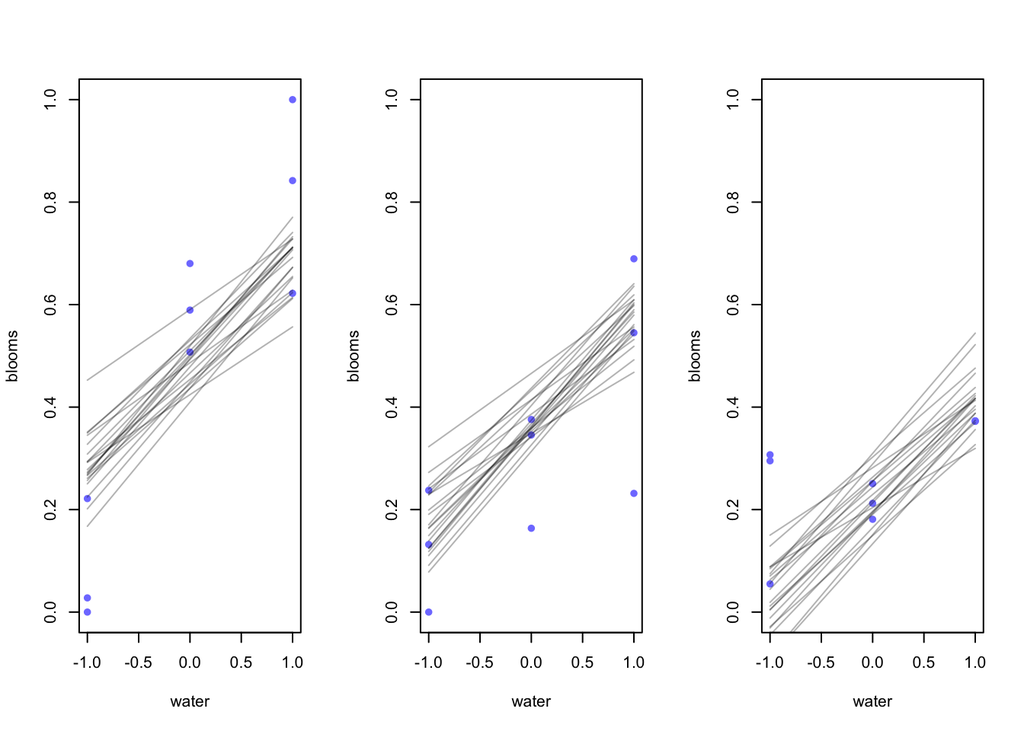

```r
par(mfrow=c(1,3)) # 3 plots in 1 row

for ( s in -1:1 ) {
  idx <- which( d$shade_cent==s )
  plot( d$water_cent[idx] , d$blooms_std[idx] , xlim=c(-1,1) , ylim=c(0,1) ,
        xlab="water" , ylab="blooms" , pch=16 , col=rangi2 )
  mu <- link( m8.6 , data=data.frame( shade_cent=s , water_cent=-1:1 ) )
  for ( i in 1:20 ) lines( -1:1 , mu[i,] , col=col.alpha("black",0.3) )
}
```

Plotting priors

code 8.26

```r
set.seed(7)
prior <- extract.prior(m8.6)
```

and plot (?)

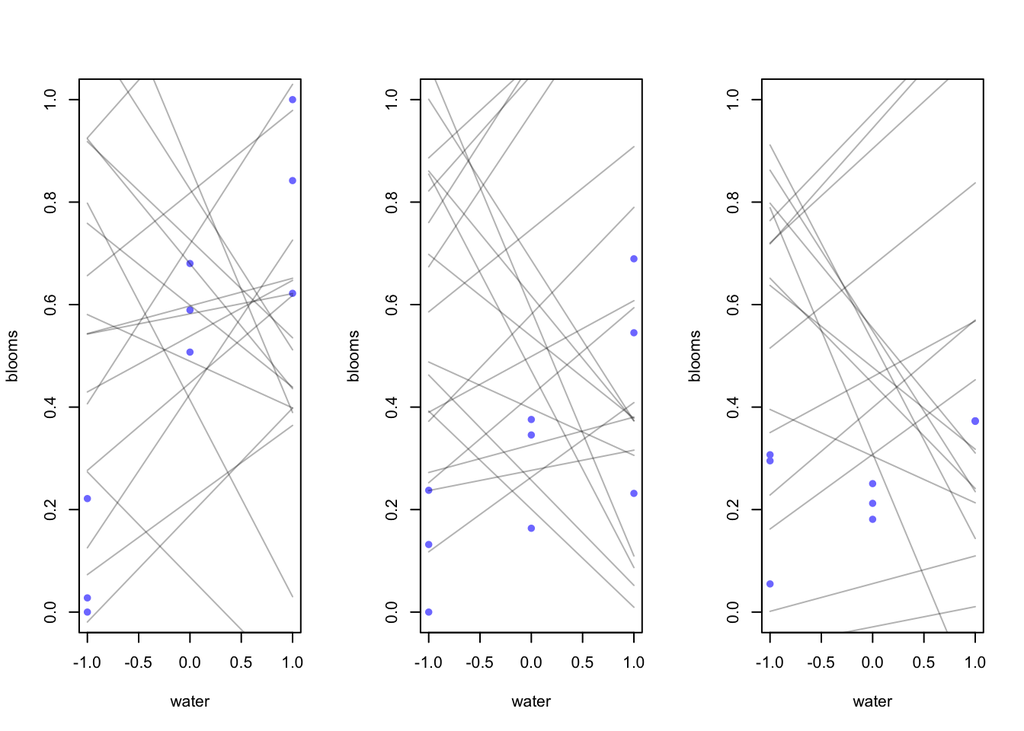

```r
par(mfrow=c(1,3)) # 3 plots in 1 row

for ( s in -1:1 ) {
  idx <- which( d$shade_cent==s )
  plot( d$water_cent[idx] , d$blooms_std[idx] , xlim=c(-1,1) , ylim=c(0,1) ,
        xlab="water" , ylab="blooms" , pch=16 , col=rangi2 )
  mu <- link( m8.6 , data=data.frame( shade_cent=s , water_cent=-1:1 ), post = prior)
  for ( i in 1:20 ) lines( -1:1 , mu[i,] , col=col.alpha("black",0.3) )
}
```

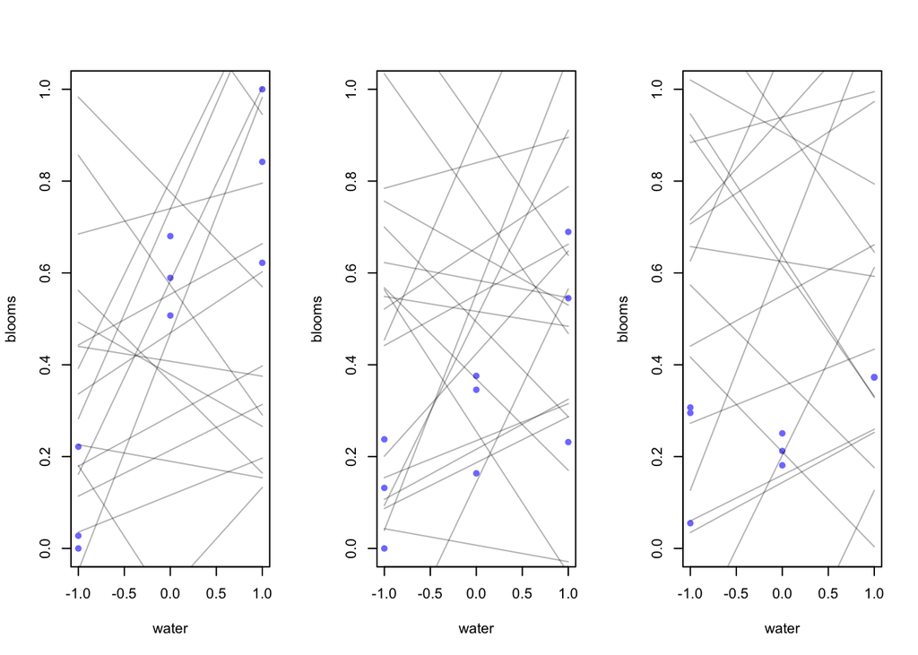

```r
prior.8.7 <- extract.prior(m8.7)

par(mfrow=c(1,3)) # 3 plots in 1 row

for ( s in -1:1 ) {
  idx <- which( d$shade_cent==s )
  plot( d$water_cent[idx] , d$blooms_std[idx] , xlim=c(-1,1) , ylim=c(0,1) ,
        xlab="water" , ylab="blooms" , pch=16 , col=rangi2 )
  mu <- link( m8.6 , data=data.frame( shade_cent=s , water_cent=-1:1 ), post = prior.8.7)
  for ( i in 1:20 ) lines( -1:1 , mu[i,] , col=col.alpha("black",0.3) )
}
```

These priors aren’t super useful (very weak) - no bias.

## Problems, p 261

### 7M1 Recall the tulips example from the chapter.

Suppose another set of treatments adjusted the temperature in the greenhouse over two levels: cold and hot. The data in the chapter were collected at the cold temperature. You find none of the plants grown under the hot temperature developed any blooms at all, regardless of the water and shade levels. Can you explain this result in terms of interactions between water, shade, and temperature?

Qualitatively, temperature interacts with both water and shade. Presumably it should be modeled continuously, but might be easier to model as categorical value.

### 7M2 Can you invent a regression equation that would make the bloom size zero, whenever the temperature is hot?

I think I want the previous equation, but with an addition that balances all to 0 when it is hot

So the temp values will be 1 (cold) and 0 (hot); and I’ll multiply them by everything else. (do I even need a beta_temp value here?)

blooms_std ~ dnorm( mu , sigma )

mu <- a + bw*water_cent*temp_cent + bt*bs*shade_cent*temp_cent + bws*water_cent*shade_cent*temp_cent

when cold, temp_cent = 1 and we have the same equation as before. when hot, temp_cemt = 0, and mu = a (the intercept)

But what if intercept is non-zero? I could set hot temp to -1. Then, when hot,

if a = bw*water_cent + bt*bs*shade_cent +* bws*water_cent*shade_cent

then mu = 0. But that seems kind of nonsensical as I would have to specify the intercept.

### 7H1 Return to the data(tulips) example in the chapter. Now include the bed variable as a predictor in the interaction model.

Don’t interact bed with the other predictors; just include it as a main effect. Note that bed is categorical. So to use it properly, you will need to either construct dummy variables or rather an index variable, as explained in Chapter ??.

see chapter 5.

```r
head(d)
```

```
##   bed water shade blooms blooms_std water_cent shade_cent
## 1   a     1     1   0.00  0.0000000         -1         -1
## 2   a     1     2   0.00  0.0000000         -1          0
## 3   a     1     3 111.04  0.3070287         -1          1
## 4   a     2     1 183.47  0.5072997          0         -1
## 5   a     2     2  59.16  0.1635791          0          0
## 6   a     2     3  76.75  0.2122159          0          1
```

```r
summary(d) # 3 beds.  make them integers.
```

```
##  bed       water       shade       blooms         blooms_std
##  a:9   Min.   :1   Min.   :1   Min.   :  0.00   Min.   :0.0000
##  b:9   1st Qu.:1   1st Qu.:1   1st Qu.: 71.11   1st Qu.:0.1966
##  c:9   Median :2   Median :2   Median :111.04   Median :0.3070
##        Mean   :2   Mean   :2   Mean   :128.99   Mean   :0.3567
##        3rd Qu.:3   3rd Qu.:3   3rd Qu.:190.30   3rd Qu.:0.5262
##        Max.   :3   Max.   :3   Max.   :361.66   Max.   :1.0000
##    water_cent   shade_cent
##  Min.   :-1   Min.   :-1
##  1st Qu.:-1   1st Qu.:-1
##  Median : 0   Median : 0
##  Mean   : 0   Mean   : 0
##  3rd Qu.: 1   3rd Qu.: 1
##  Max.   : 1   Max.   : 1
```

```r
d$bed_id <- as.numeric(d$bed)
typeof(d$bed_id )
```

```
## [1] "double"
```

old model:

```r
m8.7 <- quap(
  alist(
    blooms_std ~ dnorm( mu , sigma ) ,
    mu <- a + bw*water_cent + bs*shade_cent + bws*water_cent*shade_cent ,
    a ~ dnorm( 0.5 , 0.25 ) ,
    bw ~ dnorm( 0 , 0.25 ) ,
    bs ~ dnorm( 0 , 0.25 ) ,
    bws ~ dnorm( 0 , 0.25 ) ,
    sigma ~ dexp( 1 )
    ) ,
  data=d )
```

Now, try for a new model. have an intercept for each bed. That is, assume effects of shade and water same for all 3 beds.

```r
m7H1 <- quap(
  alist(
    blooms_std ~ dnorm( mu , sigma ) ,
    mu <- a[bed_id]  + bw*water_cent + bs*shade_cent + bws*water_cent*shade_cent ,
    a[bed_id] ~ dnorm( 0.5 , 0.25 ) ,
    bw ~ dnorm( 0 , 0.25 ) ,
    bs ~ dnorm( 0 , 0.25 ) ,
    bws ~ dnorm( 0 , 0.25 ) ,
    sigma ~ dexp( 1 )
    ) ,
  data=d )
```

### 7H2. Use WAIC to compare the model from 7H1 to a model that omits bed.

What do you infer from this comparison? Can you reconcile the WAIC results with the posterior distribution of the bed coefficients?

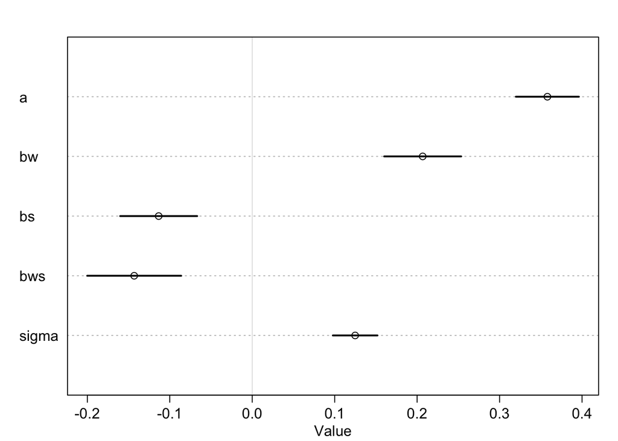

```r
plot(precis(m8.7))
```

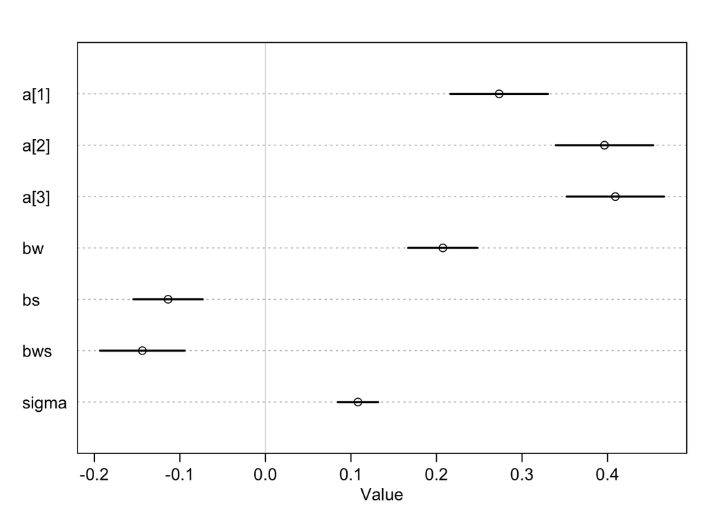

```r
plot(precis(m7H1, depth = 2))
```

```r
compare(m8.7, m7H1)
```

```
##           WAIC    pWAIC    dWAIC    weight        SE      dSE
## m7H1 -23.70421 9.636192 0.000000 0.6921953  9.717591       NA
## m8.7 -22.08341 6.647359 1.620806 0.3078047 10.593409 8.210327
```

It seems the more complex model is very slightly preferred according to WAIC

Let’s peek at the posteriors (p 195 and p 259)

First, non-bed model. want to plot tryptich, looping over the 3 beds

```r
head(d)
```

```
##   bed water shade blooms blooms_std water_cent shade_cent bed_id
## 1   a     1     1   0.00  0.0000000         -1         -1      1
## 2   a     1     2   0.00  0.0000000         -1          0      1
## 3   a     1     3 111.04  0.3070287         -1          1      1
## 4   a     2     1 183.47  0.5072997          0         -1      1
## 5   a     2     2  59.16  0.1635791          0          0      1
## 6   a     2     3  76.75  0.2122159          0          1      1
```

```r
#par(mfrow=c(1,3)) # 3 plots in 1 row
#for ( s in 1:3 ) {
#  idx <- which( d$bed_id==s )
#  plot( d$water_cent[idx] , d$blooms_std[idx] , xlim=c(-1,1) , ylim=c(0,1) ,
#        xlab="water" , ylab="blooms" , pch=16 , col=rangi2 )
#  mu <- link( m8.7 , data=data.frame( bed_id=s , water_cent=-1:1 ) )
#  for ( i in 1:20 ) lines( -1:1 , mu[i,] , col=col.alpha("black",0.3) )
#}
```

huh, won’t let me plot without specifying shade as well. I guess I“ll just recapitulate previous plots.

```r
#par(mfrow=c(1,3)) # 3 plots in 1 row

#for ( s in -1:1 ) {
#  idx <- which( d$shade_cent==s )
#  plot( d$water_cent[idx] , d$blooms_std[idx] , xlim=c(-1,1) , ylim=c(0,1) ,
#        xlab="water" , ylab="blooms" , pch=16 , col=rangi2 )
#  mu <- link( m8.7 , data=data.frame( shade_cent=s , water_cent=-1:1 ), post = prior)
#  for ( i in 1:20 ) lines( -1:1 , mu[i,] , col=col.alpha("black",0.3) )
#}
```

Doesn’t like this because ‘object bws not found’. I don’t know why that matters. the example plots worked fine.

### 7H4. The values in data(nettle) are data on language diversity in 74 nations.

Use these data to evaluate the hypothesis that language diversity is partly a product of food security.

```r
data(nettle)
d.lang <- nettle
```

set up as directed

```r
d.lang$lang.per.cap <- d.lang$num.lang / d.lang$k.pop
```

Instructions:

want log of lang.per.cap want log of area

```r
d.lang$log.lang.cap <- log(d.lang$lang.per.cap)
d.lang$log.area <- log(d.lang$area)
```

should I normalize/center any of this? I’ll be modeling log.lang.cap, log.area, mean.growing.season, sd.growing.season

```r
summary(d.lang)
```

```
##        country      num.lang           area             k.pop
##  Algeria   : 1   Min.   :  1.00   Min.   :  12189   Min.   :   102
##  Angola    : 1   1st Qu.: 17.25   1st Qu.: 167708   1st Qu.:  3829
##  Australia : 1   Median : 40.00   Median : 434796   Median :  9487
##  Bangladesh: 1   Mean   : 89.73   Mean   : 880698   Mean   : 33574
##  Benin     : 1   3rd Qu.: 93.75   3rd Qu.:1080316   3rd Qu.: 24744
##  Bolivia   : 1   Max.   :862.00   Max.   :8511965   Max.   :849638
##  (Other)   :68
##   num.stations    mean.growing.season sd.growing.season
##  Min.   :  1.00   Min.   : 0.000      Min.   :0.0000
##  1st Qu.: 10.00   1st Qu.: 5.348      1st Qu.:0.9375
##  Median : 20.50   Median : 7.355      Median :1.6900
##  Mean   : 37.91   Mean   : 7.041      Mean   :1.6992
##  3rd Qu.: 44.75   3rd Qu.: 9.283      3rd Qu.:2.1075
##  Max.   :272.00   Max.   :12.000      Max.   :5.8700
##
##   lang.per.cap        log.lang.cap        log.area
##  Min.   :0.0000931   Min.   :-9.2814   Min.   : 9.408
##  1st Qu.:0.0019901   1st Qu.:-6.2196   1st Qu.:12.029
##  Median :0.0041066   Median :-5.4952   Median :12.981
##  Mean   :0.0206464   Mean   :-5.4566   Mean   :12.935
##  3rd Qu.:0.0100059   3rd Qu.:-4.6111   3rd Qu.:13.892
##  Max.   :0.6809816   Max.   :-0.3842   Max.   :15.957
##
```